# Chess Elo Prediction — 1D CNN over Move Sequences

**Architecture:** Multi-scale 1D CNN replacing the BiLSTM in v4. Three parallel convolutional branches with kernel sizes 3, 5, and 7 capture short, medium, and longer-range move patterns simultaneously. Global max-pooling produces a fixed-size vector regardless of game length.

**Why it might work better:** CNNs parallelise fully over the sequence dimension — no sequential dependency at all — making them considerably faster than LSTMs on CPU. Multiple kernel sizes are useful here because chess patterns operate at different scales: a local tactic might span 3 moves, while a strategic plan could take 7 moves to execute. Capturing both simultaneously and letting the model decide which is relevant is a known strength of multi-scale convolution (it's how TextCNN works for text classification).

**Honest tradeoff:** CNNs have bounded receptive fields (max 7 moves here). Very long-range dependencies — a positional weakness established in move 10 that only matters in move 50 — are invisible to the CNN unless the filters happen to catch them by coincidence. This is the opposite failure mode from LSTMs, which can in principle see long-range context but tend to forget it in practice. Whether chess games actually have important long-range dependencies that LSTMs exploit is unclear, which is exactly why this experiment is worth running.

**Baseline to beat:** v4 combined MAE ≈ 200 Elo.

## Config

```
Device : cpu  |  AMP : False  |  CPU threads : 12
Sequential=True  |  AE=False  |  DistTarget=True
MAX_GAMES=1,000,000  |  N_FILTERS=128  |  Kernels=(3,5,7)
```

## Data Loading

```
Loaded 1,000,000 games in 41.5s
Removed 336,739 games by termination type
Kept 534,045 games after filters (removed 126,381)
Elo range — White: 761–2812,  Black: 758–2918
```

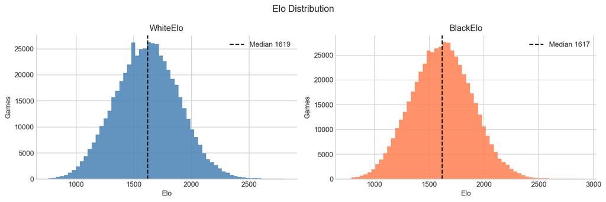

## Feature Extraction

```
Board features loaded from cache  (35 cols)
Clock features loaded from cache  (10 cols)
Full feature matrix: (534045, 69)
```

## Move Tokenisation

```
Dropped 7,049 games shorter than 12 plies
Vocabulary size : 10,199
Games ready     : 526,996
```

## Soft Distribution Targets

```
1600 Elo dist: peak at 1550,  recovered = 1600
```

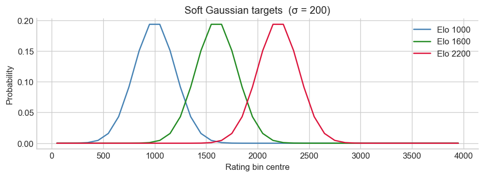

## Feature Selection, Train/Val/Test Split & Scaling

```
Static feature columns selected: 45
Split — train: 421,596  val: 52,700  test: 52,700
Scaling done (StandardScaler fit on train only)
```

## Dataset & DataLoaders

```
Building datasets...
  Built in 155s   static dim = 45
Batches per epoch: 3,294
```

## Model — Multi-Scale 1D CNN

**Sequence branch:** token embedding (with clock + turn appended) → three parallel Conv1d branches with kernel sizes 3, 5, 7 → global max-pool each → concatenate (3 × N_FILTERS features).

**Static branch:** same MLP as v4.

**Fusion:** concat CNN output + static → shared trunk → two output heads.

Padding ensures all convolutions produce the same sequence length before max-pool.

```
Model built — 947,568 trainable parameters  |  N_FILTERS=128  seq_dim=384
```

## Hyperparameter Optimisation (Optuna)

15 trials on a 50k-game subset, 3 training epochs each. Searches:

- `n_filters`: filters per CNN branch {64, 128, 256}
- `embed_dim`: move embedding dimension {32, 64, 128}
- `dropout`: regularisation strength {0.1 … 0.4}

Kernel sizes (3, 5, 7) are fixed as the architectural choice — they define the model identity.

```
Best trial  val_loss=0.7549
Best params: {'n_filters': 64, 'embed_dim': 128, 'dropout': 0.11161755998835499}

Full training will use: n_filters=64  embed_dim=128  dropout=0.112
```

## Training

```
Epoch  1/10  train 0.9558  val 0.8765  MAE W:185 B:182  lr 2.93e-04  594.3s
Epoch  2/10  train 0.6577  val 0.8450  MAE W:178 B:176  lr 2.73e-04  593.4s
Epoch  3/10  train 0.5768  val 0.7883  MAE W:169 B:170  lr 2.41e-04  591.6s
Epoch  4/10  train 0.5313  val 0.7942  MAE W:170 B:170  lr 2.02e-04  599.0s
Epoch  5/10  train 0.4990  val 0.7649  MAE W:165 B:166  lr 1.57e-04  592.1s
Epoch  6/10  train 0.4748  val 0.7582  MAE W:164 B:165  lr 1.13e-04  589.2s
Epoch  7/10  train 0.4578  val 0.7580  MAE W:164 B:166  lr 7.37e-05  592.3s
Epoch  8/10  train 0.4410  val 0.7841  MAE W:166 B:168  lr 4.22e-05  586.4s
Epoch  9/10  train 0.4310  val 0.7755  MAE W:165 B:166  lr 2.20e-05  592.2s
Early stopping at epoch 9
```

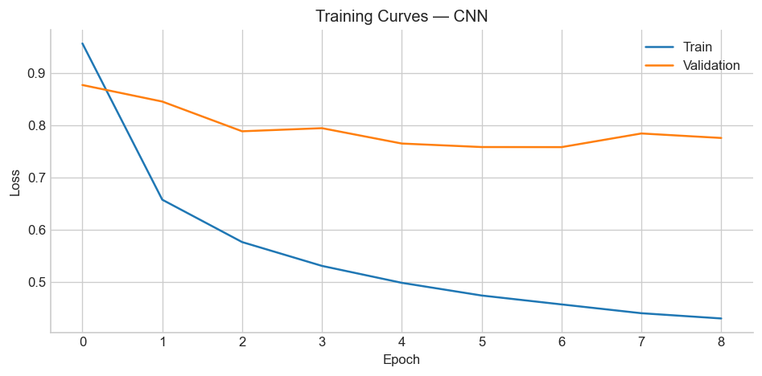

## Evaluation

```
Loaded checkpoint: checkpoints\cnn_1e+06.pth
MAE    — White: 165.1  Black: 165.4  Combined: 165.2
Median — White: 133.3  Black: 134.5
Within 100 Elo: 38.7%
Within 200 Elo: 67.8%
Within 300 Elo: 85.0%
```

```
==================================================
  Architecture Comparison
==================================================
  v4 (BiLSTM + AE)       combined MAE ≈ 200.0
  CNN (this)             combined MAE  = 165.2
  Δ = -34.8 Elo  (better than baseline)
==================================================
```

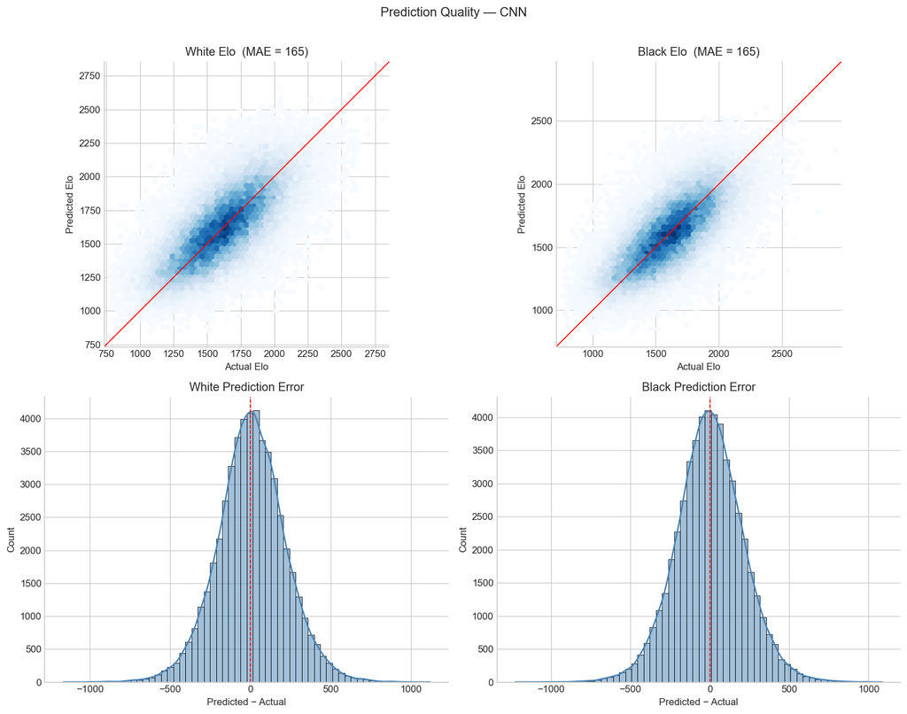

```
MAE by Elo bracket:
------------------------------------------
           (0, 1000]  MAE =   294  n = 895
        (1000, 1200]  MAE =   191  n = 5,760
        (1200, 1400]  MAE =   157  n = 16,143
        (1400, 1600]  MAE =   151  n = 26,916
        (1600, 1800]  MAE =   155  n = 28,615
        (1800, 2000]  MAE =   169  n = 18,366
        (2000, 2200]  MAE =   201  n = 6,784
        (2200, 2500]  MAE =   278  n = 1,813
        (2500, 4000]  MAE =   438  n = 108
```

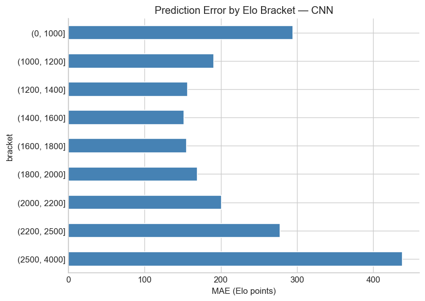

## Predicted Rating Distributions

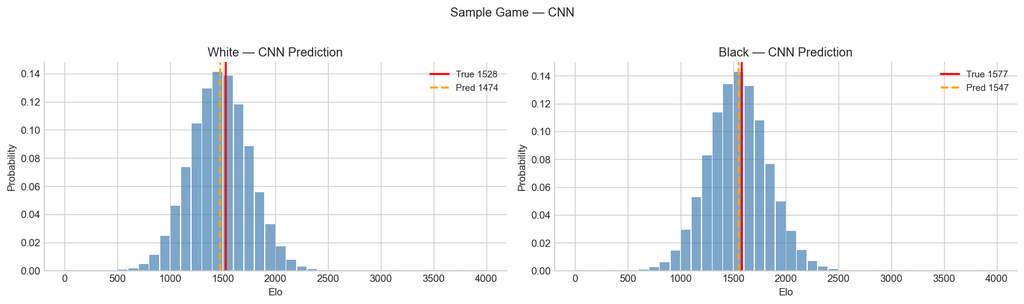

## Latent Space — t-SNE & PCA

```
Running t-SNE on 3000 vectors...
```

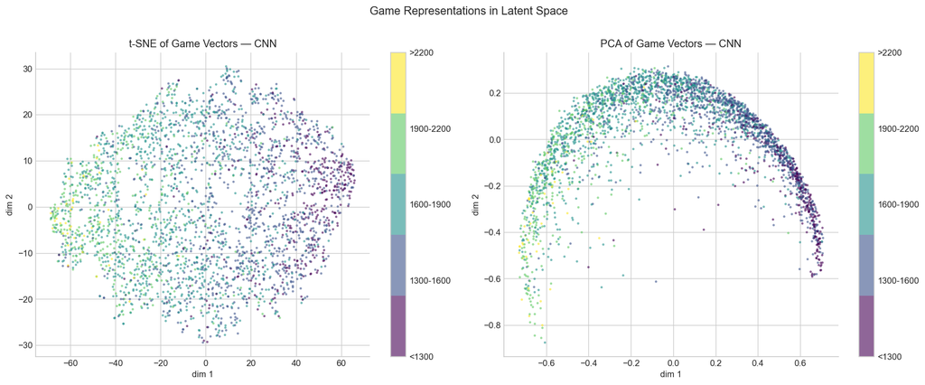

## Feature Group Importance

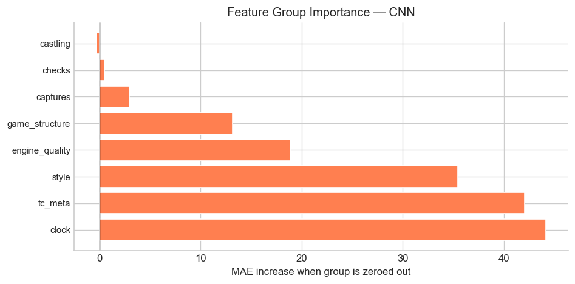

```
  clock               Δ = +44.2
  tc_meta             Δ = +42.1
  style               Δ = +35.4
  engine_quality      Δ = +18.8
  game_structure      Δ = +13.1
  captures            Δ = +3.0
  checks              Δ = +0.5
  castling            Δ = -0.3
```

## Anomaly Detection

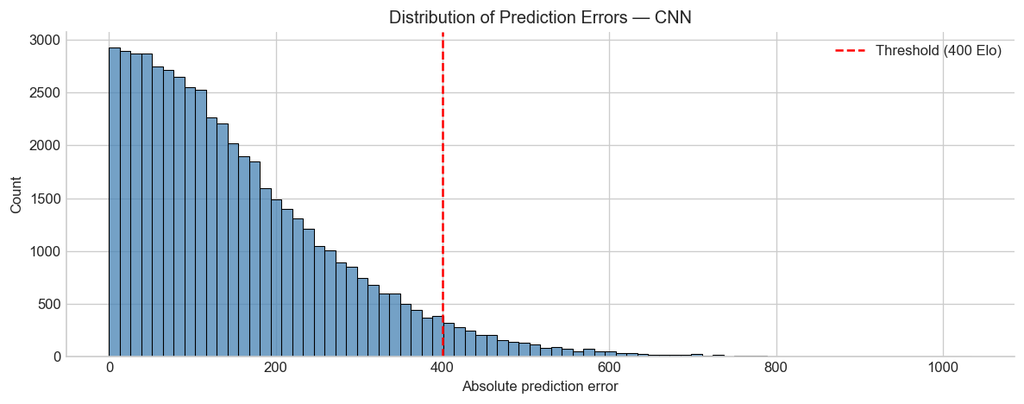

```
Flagged 2650 games with error > 400 Elo  (5.0%)
```

## Single-Game Inference

```
=============================================
  White Elo   predicted:  1941   actual: 1546
  Black Elo   predicted:  1868   actual: 1534
=============================================
```

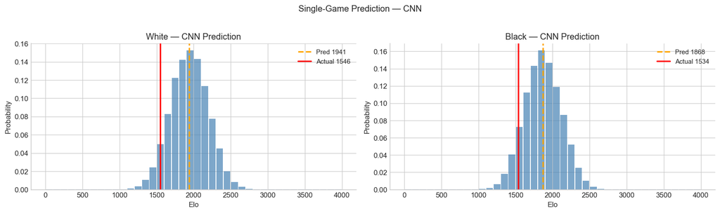

## Export

[output not shown]